# How Well can we Predict the Popularity of a Song?

# Preliminary Data Analysis - Correlation Plot Between Features

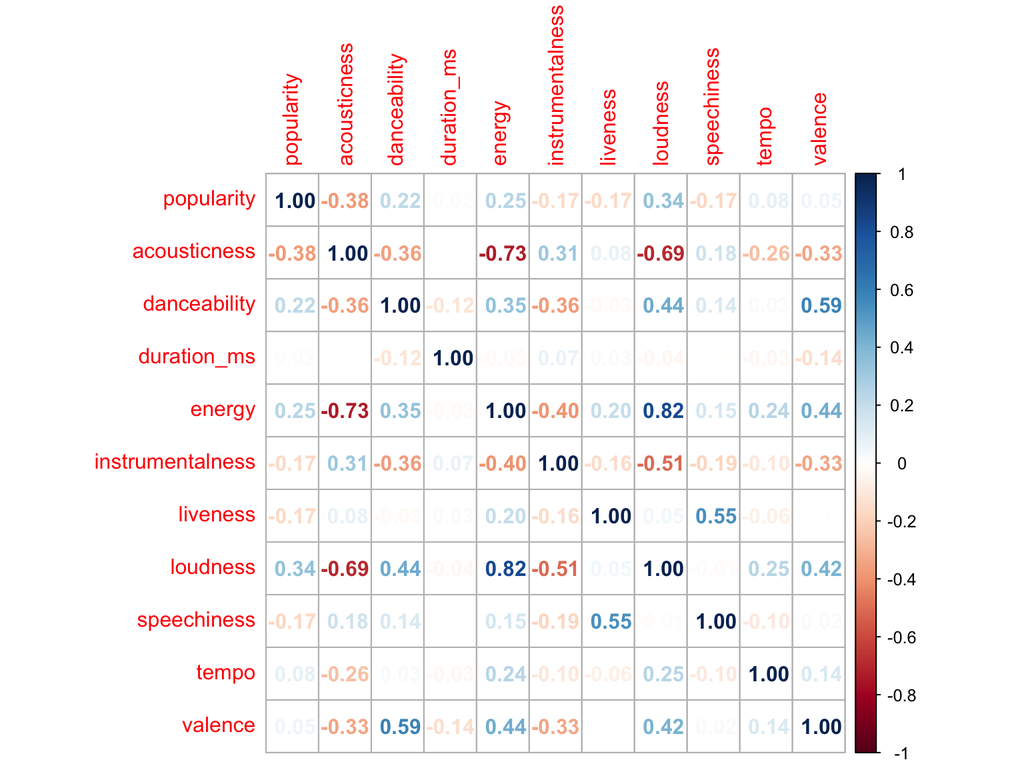

# Preliminary Data Analysis - Loudness Plot

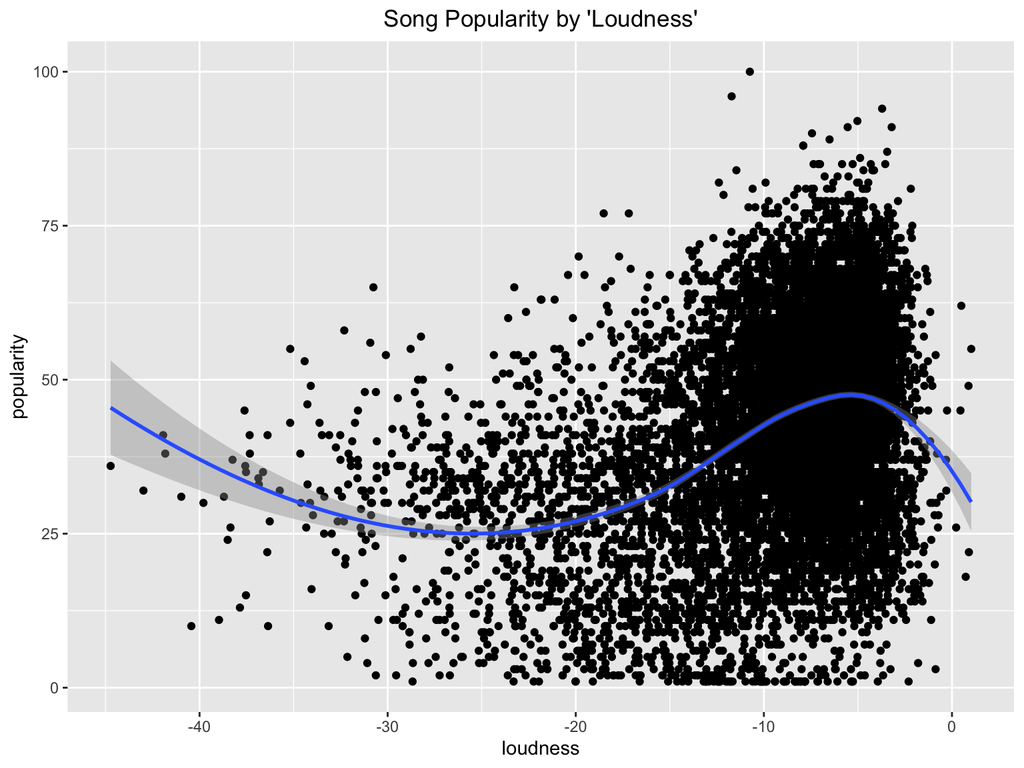

# Preliminary Data Analysis - Danceability Plot

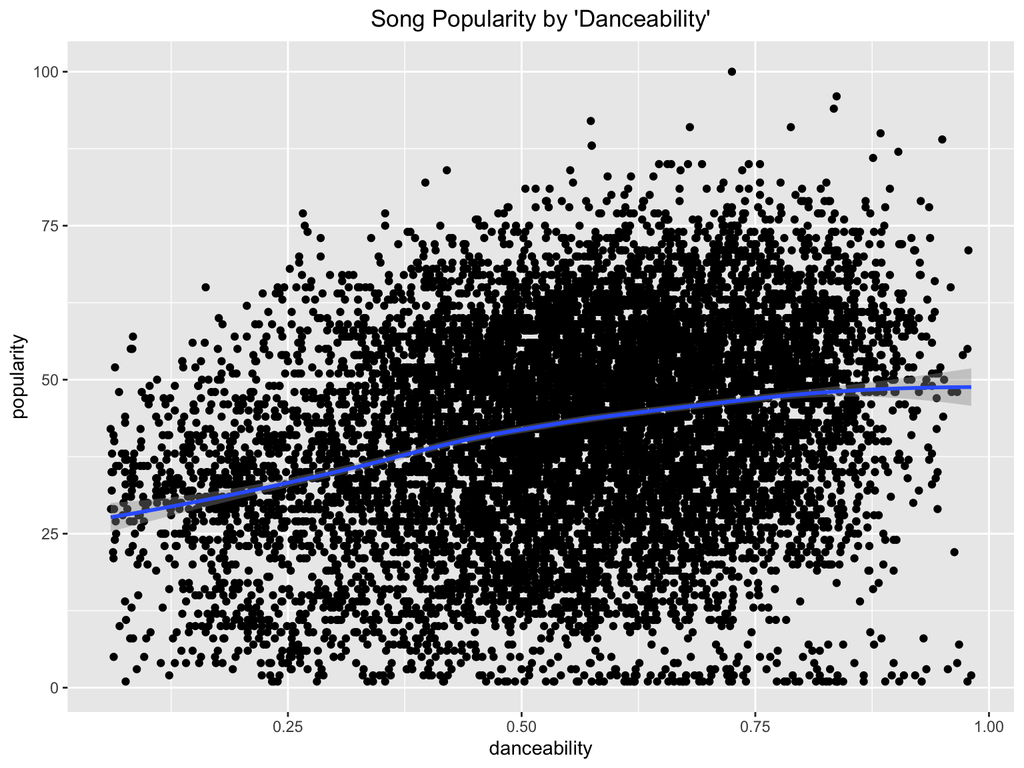

# Preliminary Data Analysis - Acousticness Plot

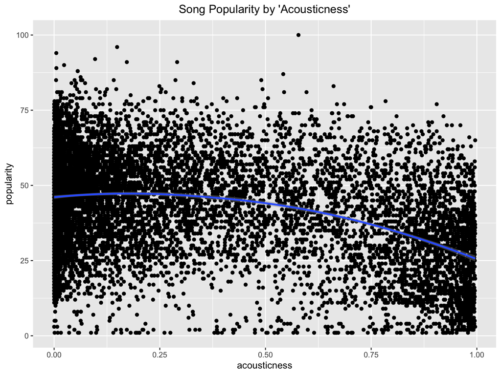

# Random Forest with All Genres - First Model

```
## [1] "Initial mtry value: 3.60555127546399"
```

```
## [1] "RMSE of our first RF model is: 15.4594981812402"
```

# Look at variable importance

|  | Overall |
| --- | --- |
| acousticness | 3841.0445 |
| danceability | 2250.1343 |
| duration_ms | 2993.5943 |
| energy | 2658.1052 |
| instrumentalness | 1599.8494 |
| key | 3672.9501 |
| liveness | 2068.6330 |
| loudness | 3687.1308 |
| mode | 200.6078 |
| speechiness | 2003.7502 |
| tempo | 1661.8719 |
| time_signature | 377.4922 |
| valence | 2046.0900 |

# Optimizing the model

### To optimize the model we tuned the mtry hyperparameter. We found that when run on our tune dataset 2 was a more accurate mtry value as opposed to 4 when we had originally created the model. In response to this we created another model with the mtry set to 2. This gave better results (both rmse and nrmse) when run on our test dataset.

# Creating the Tuned Model

```
## [1] "RMSE of original model: 15.4594981812402"
```

```
## [1] "RMSE of optimized model: 14.5223043796896"
```

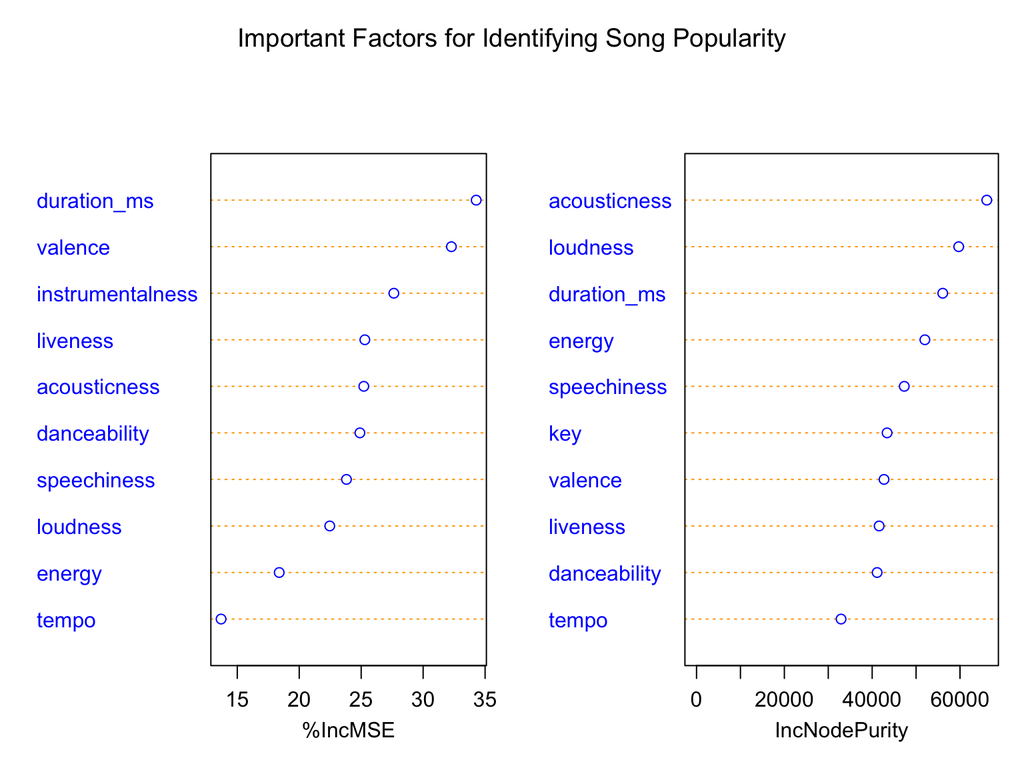

# Testing the Model

### After testing the model we found an rmse of around 14.1 and a nrmse of around .16

```
## [1] "pop_RF_2 rmse: 14.1544440007784"
```

```
## [1] "pop_RF_2 test NRMSE: 0.164586558148585"
```

# Exploration With Focused Data

We followed the same steps as above when working with 6 other datasets: rap music, jazz music, country music, songs by Kenny Chesney, Miles Davis, and Drake.